# Multiple regression analysis: Estimation

SW

2022/7/25

## Key terms

- Multiple regression analysis
- Frisch-Waugh-Lovell theorem
- Disturbance term
- Residual
- Residual sum of squares, *RSS*
- Ordinary least squares, *OLS*
- Normal equations
- Demeaning
- Goodness of fit
- Total sum of squares, *TSS*
- Explained sum of squares, *ESS*
- Coefficient of determination: $R^2$

## 1. A model with two explanatory variables

```r
# Load the required package
library(tidyverse)

eawe21 <- read.csv('./Data/EAWE21.csv', header=T)

lm(EARNINGS ~ S + EXP, data = eawe21) %>%
  summary
```

```
##
## Call:
## lm(formula = EARNINGS ~ S + EXP, data = eawe21)
##
## Residuals:
##     Min      1Q  Median      3Q     Max
## -21.098  -6.440  -2.113   3.782  76.907
##
## Coefficients:
##             Estimate Std. Error t value Pr(>|t|)
## (Intercept) -14.6683     4.2884  -3.420 0.000677 ***
## S             1.8776     0.2237   8.392 5.01e-16 ***
## EXP           0.9833     0.2098   4.686 3.60e-06 ***
## ---
## Signif. codes:  0 '***' 0.001 '**' 0.01 '*' 0.05 '.' 0.1 ' ' 1
##
## Residual standard error: 11.13 on 497 degrees of freedom
## Multiple R-squared:  0.1242, Adjusted R-squared:  0.1207
## F-statistic: 35.24 on 2 and 497 DF,  p-value: 4.86e-15
```

**Figure 3.2 at p. 163**

```r
eawe21 <- read.csv('./Data/EAWE21.csv', header=T)

SRM <- lm(EARNINGS ~ S, data = eawe21)
summary(SRM)
```

```
##
## Call:
## lm(formula = EARNINGS ~ S, data = eawe21)
##
## Residuals:
##     Min      1Q  Median      3Q     Max
## -20.079  -6.726  -2.203   3.451  79.037
##
## Coefficients:
##             Estimate Std. Error t value Pr(>|t|)
## (Intercept)   0.7647     2.8038   0.273    0.785
## S             1.2657     0.1855   6.824 2.58e-11 ***
## ---
## Signif. codes:  0 '***' 0.001 '**' 0.01 '*' 0.05 '.' 0.1 ' ' 1
##
## Residual standard error: 11.36 on 498 degrees of freedom
## Multiple R-squared:  0.08551,    Adjusted R-squared:  0.08368
## F-statistic: 46.57 on 1 and 498 DF,  p-value: 2.579e-11
```

```r
EEARN = eawe21$EARNINGS - fitted.values(lm(EARNINGS ~ EXP, data = eawe21))
ES = eawe21$S - fitted.values(lm(S ~ EXP, data = eawe21))

RegOnResid <- lm(EEARN ~ ES)
summary(RegOnResid)
```

```
##
## Call:
## lm(formula = EEARN ~ ES)
##
## Residuals:
##     Min      1Q  Median      3Q     Max
## -21.098  -6.440  -2.113   3.782  76.907
##
## Coefficients:
##              Estimate Std. Error t value Pr(>|t|)
## (Intercept) 2.108e-17  4.974e-01     0.0        1
## ES          1.878e+00  2.235e-01     8.4 4.69e-16 ***
## ---
## Signif. codes:  0 '***' 0.001 '**' 0.01 '*' 0.05 '.' 0.1 ' ' 1
##
## Residual standard error: 11.12 on 498 degrees of freedom
## Multiple R-squared:  0.1241, Adjusted R-squared:  0.1223
## F-statistic: 70.56 on 1 and 498 DF,  p-value: 4.688e-16
```

```r
# Print the coefficient
RegOnResid$coefficient[2]
```

```
##       ES
## 1.877563
```

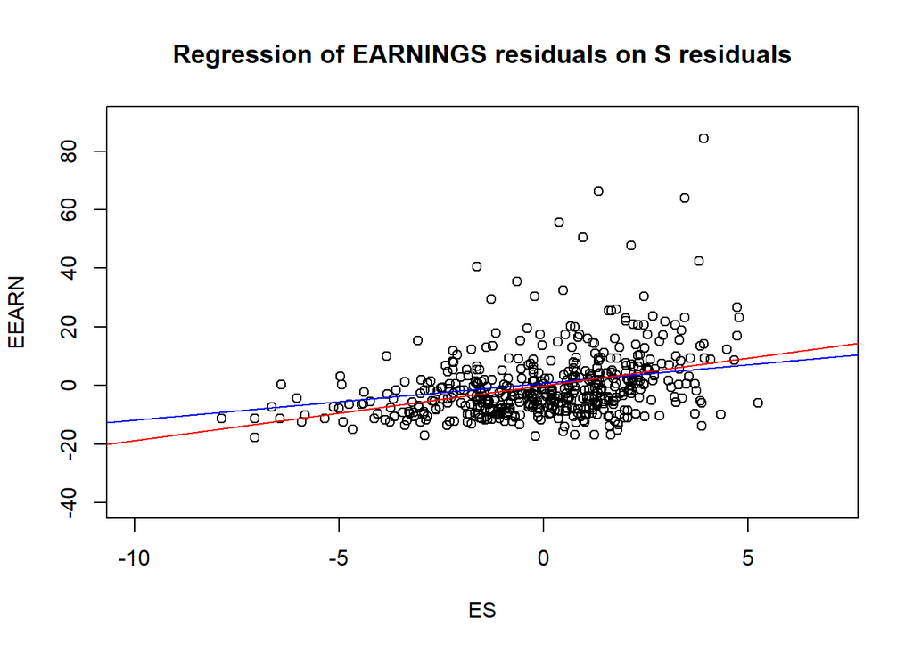

```r
plot(EEARN ~ ES,
     main = "Regression of EARNINGS residuals on S residuals",
     xlab = "ES",
     ylab = "EEARN",
     xlim = c(-10, 7),
     ylim = c(-40, 90))

abline(SRM, col='blue')              # Add the regression line
abline(RegOnResid, col="red")
```

# Alternate way to perform the example

```r
# The full model
FullModel <- lm(EARNINGS ~ S + EXP, data = eawe21)
# Regression of X on X
X_on_X <- lm(S ~ EXP, data = eawe21)
# Regression of Y on r
Y_on_r <- lm(EARNINGS ~ X_on_X$residuals, data = eawe21)

# Print the coefficients
FullModel$coefficients[2]
```

```
##        S
## 1.877563
```

```r
Y_on_r$coefficients[2]
```

```
## X_on_X$residuals
##         1.877563
```

**Table 3.3 at p. 168**

```r
# Regression of EARNINGS on S and EXP
# with wages set by collective bargaining

# Load the required package
library(tidyverse)

# Create the dataset
eawe21.1 <- read.csv('./Data/EAWE21.csv', header=T) %>%    # Input the data
  filter(COLLBARG == 1)                                    # Filter the data

# Run the model
lin.model.1 <- lm(EARNINGS ~ S + EXP, data = eawe21.1)

# Regression result
summary(lin.model.1)
```

```
##
## Call:
## lm(formula = EARNINGS ~ S + EXP, data = eawe21.1)
##
## Residuals:
##     Min      1Q  Median      3Q     Max
## -17.365  -7.418  -2.308   6.794  38.736
##
## Coefficients:
##             Estimate Std. Error t value Pr(>|t|)
## (Intercept)   1.0171    10.8470   0.094   0.9256
## S             1.4295     0.5365   2.665   0.0095 **
## EXP           0.1919     0.5902   0.325   0.7460
## ---
## Signif. codes:  0 '***' 0.001 '**' 0.01 '*' 0.05 '.' 0.1 ' ' 1
##
## Residual standard error: 10.44 on 72 degrees of freedom
## Multiple R-squared:  0.1159, Adjusted R-squared:  0.09134
## F-statistic: 4.719 on 2 and 72 DF,  p-value: 0.01186
```

```r
anova(lin.model.1)
```

```
## Analysis of Variance Table
##
## Response: EARNINGS
##           Df Sum Sq Mean Sq F value   Pr(>F)
## S          1 1016.4 1016.41  9.3327 0.003155 **
## EXP        1   11.5   11.51  0.1057 0.746046
## Residuals 72 7841.4  108.91
## ---
## Signif. codes:  0 '***' 0.001 '**' 0.01 '*' 0.05 '.' 0.1 ' ' 1
```

**Table 3.4 at p. 168**

```r
# Regression of EARNINGS on S and EXP
# with wages set by other than collective bargaining

# Create the dataset
eawe21.0 <- read.csv('./Data/EAWE21.csv', header=T) %>%    # Input the data
  filter(COLLBARG == 0)                                    # Filter the data

# Run the model
lin.model.0 <- lm(EARNINGS ~ S + EXP, data = eawe21.0)


# Regression result
summary(lin.model.0)
```

```
##
## Call:
## lm(formula = EARNINGS ~ S + EXP, data = eawe21.0)
##
## Residuals:
##     Min      1Q  Median      3Q     Max
## -20.486  -6.395  -1.980   3.602  77.732
##
## Coefficients:
##             Estimate Std. Error t value Pr(>|t|)
## (Intercept) -15.9847     4.6238  -3.457 0.000602 ***
## S             1.8663     0.2439   7.652 1.35e-13 ***
## EXP           1.1002     0.2223   4.949 1.08e-06 ***
## ---
## Signif. codes:  0 '***' 0.001 '**' 0.01 '*' 0.05 '.' 0.1 ' ' 1
##
## Residual standard error: 11.11 on 422 degrees of freedom
## Multiple R-squared:  0.1226, Adjusted R-squared:  0.1184
## F-statistic: 29.48 on 2 and 422 DF,  p-value: 1.039e-12
```

```r
anova(lin.model.0)
```

```
## Analysis of Variance Table
##
## Response: EARNINGS
##            Df Sum Sq Mean Sq F value    Pr(>F)
## S           1   4251  4250.8  34.468 8.782e-09 ***
## EXP         1   3020  3020.0  24.488 1.082e-06 ***
## Residuals 422  52043   123.3
## ---
## Signif. codes:  0 '***' 0.001 '**' 0.01 '*' 0.05 '.' 0.1 ' ' 1
```

(See the online reference on linear regression from Prof. Alexandra Chouldechova at the following website: https://www.andrew.cmu.edu/user/achoulde/94842/lectures/lecture09/lecture09-94842.html)

More information can be found in teaching website of Prof. Alexandra Chouldechova (https://www.andrew.cmu.edu/user/achoulde/)

**Example of multicollinearity (p. 174 Table 3.7)**

```r
lm(S ~ ASVABC + SM + SF, data = eawe21) %>%
  summary
```

```
##
## Call:
## lm(formula = S ~ ASVABC + SM + SF, data = eawe21)
##
## Residuals:
##     Min      1Q  Median      3Q     Max
## -5.9387 -1.6521  0.0186  1.5161  7.1553
##
## Coefficients:
##             Estimate Std. Error t value Pr(>|t|)
## (Intercept) 10.59674    0.61428  17.251  < 2e-16 ***
## ASVABC       1.24253    0.12359  10.054  < 2e-16 ***
## SM           0.09135    0.04593   1.989   0.0473 *
## SF           0.20289    0.04251   4.773  2.4e-06 ***
## ---
## Signif. codes:  0 '***' 0.001 '**' 0.01 '*' 0.05 '.' 0.1 ' ' 1
##
## Residual standard error: 2.254 on 496 degrees of freedom
## Multiple R-squared:  0.329,  Adjusted R-squared:  0.3249
## F-statistic: 81.06 on 3 and 496 DF,  p-value: < 2.2e-16
```

```r
# correlation between SM and SF
with(eawe21, cor(SM, SF))
```

```
## [1] 0.5312147
```

The correlation coefficient of SM and SF is 0.5312147.

**Example of multicollinearity (p. 175 Table 3.8)**

```r
eawe21 <- eawe21 %>%
  mutate(EXPSQ = EXP^2)

lm(EARNINGS ~ S + EXP + EXPSQ, data = eawe21) %>%
  summary
```

```
##
## Call:
## lm(formula = EARNINGS ~ S + EXP + EXPSQ, data = eawe21)
##
## Residuals:
##     Min      1Q  Median      3Q     Max
## -21.323  -6.412  -2.140   3.771  76.675
##
## Coefficients:
##              Estimate Std. Error t value Pr(>|t|)
## (Intercept) -15.76580    4.57953  -3.443 0.000625 ***
## S             1.86928    0.22419   8.338  7.5e-16 ***
## EXP           1.42785    0.68149   2.095 0.036661 *
## EXPSQ        -0.03284    0.04790  -0.686 0.493281
## ---
## Signif. codes:  0 '***' 0.001 '**' 0.01 '*' 0.05 '.' 0.1 ' ' 1
##
## Residual standard error: 11.14 on 496 degrees of freedom
## Multiple R-squared:  0.125,  Adjusted R-squared:  0.1197
## F-statistic: 23.63 on 3 and 496 DF,  p-value: 2.62e-14
```

**Table 3.11 on p. 179*

```r
eawe21 <- eawe21 %>%
  mutate(SP = SM + SF)

lm(S ~ ASVABC + SP, data = eawe21) %>%
  summary
```

```
##
## Call:
## lm(formula = S ~ ASVABC + SP, data = eawe21)
##
## Residuals:
##     Min      1Q  Median      3Q     Max
## -6.0214 -1.6087  0.0306  1.5129  6.6917
##
## Coefficients:
##             Estimate Std. Error t value Pr(>|t|)
## (Intercept) 10.50285    0.61170  17.170  < 2e-16 ***
## ASVABC       1.24320    0.12373  10.047  < 2e-16 ***
## SP           0.15008    0.02299   6.529 1.64e-10 ***
## ---
## Signif. codes:  0 '***' 0.001 '**' 0.01 '*' 0.05 '.' 0.1 ' ' 1
##
## Residual standard error: 2.256 on 497 degrees of freedom
## Multiple R-squared:  0.326,  Adjusted R-squared:  0.3233
## F-statistic: 120.2 on 2 and 497 DF,  p-value: < 2.2e-16
```

**Diagnostic plots**

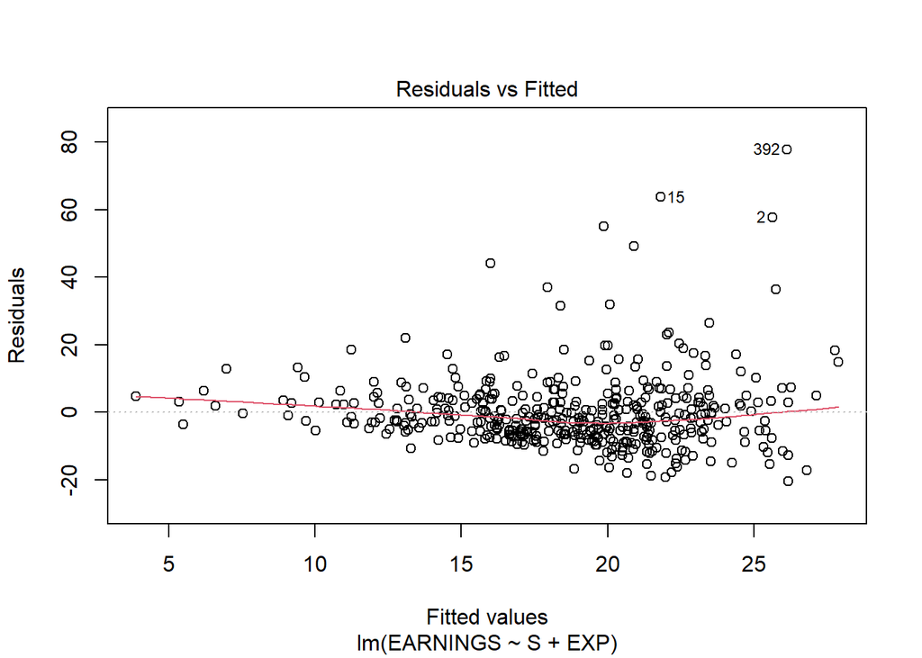

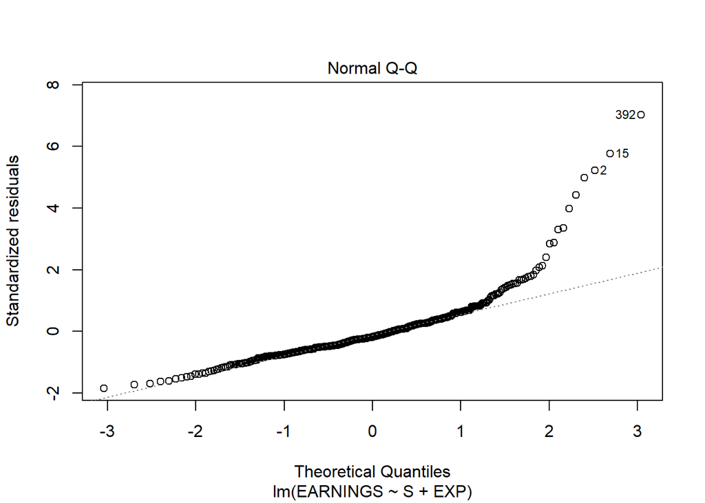

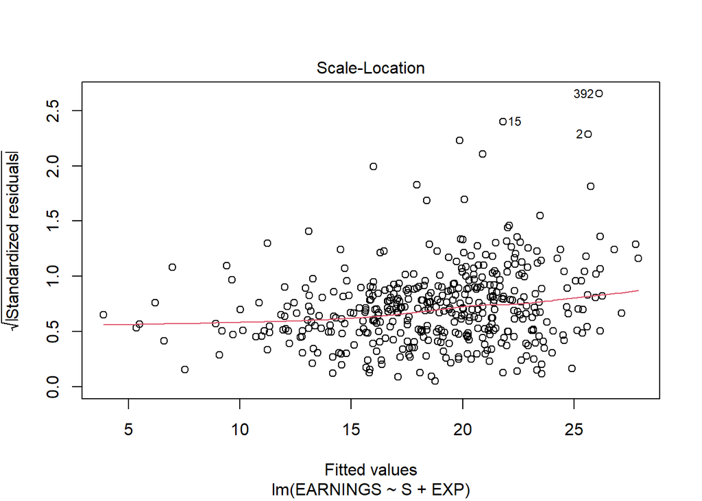

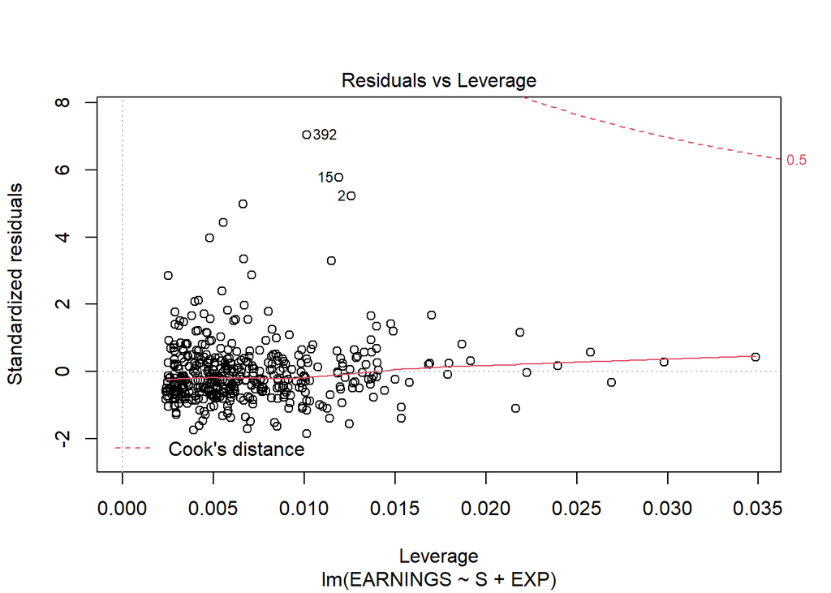

```r
# plot(lin.model.0, which=1)
plot(lin.model.0, which = c(1,2,3,5))
```

Use the following command to check what diagnostic plots available in r

```r
?plot.lm
```

# A proper way to introduce a discussion of the estimates

I estimated the equation by ordinary least squares. Under the assumption that no important variables have been omitted from the equation, and assuming random sampling, the OLS estimator of the $x_1$ effect, $\beta_1$, is unbiased. If the error term $u$ has constant variance, the OLS estimator is actually best linear unbiased.

Adapted from pp. 97 of @Wooldridge.

# Old materials below

The difference between the actual value of $Y_{i}$ and the fitted value $\hat{Y_{i}}$, in observation $i$ is known as the **residual** in the observation $i$. It will be denoted :

$$\hat{u}_{i}=Y_{i}-\hat{Y_{i}}$$

## 2. Derivation of the regression coefficients

We use the **least squares** criterion to choose $\hat{\beta_{1}}$ amd $\hat{\beta_{2}}$ so as to minimize **RSS**, the **residual sum of squares** (sum of the squares of the residuals).

$$RSS=\sum_{i=1}^{n}{\hat{u}_{i}}^2$$
This is usually referred to as **ordinary least squares** and abbreviated **OLS**.
The square of the residual in observation $i$ in terms of $\hat{\beta_{1}}$ and $\hat{\beta_{2}}$, and the data on $X$ and $Y$:

$$\begin{eqnarray}
{\hat{u}_{i}}^2 &=&(Y_i-\hat{Y}_{i})^2 =(Y_i-\hat{\beta}_{1}-\hat{\beta}_{2}X_i)^2 \\
&=& Y_i^2+\hat{\beta}_{1}^2+\hat{\beta}_{2}^2X_i^2-2\hat{\beta}_{1}Y_i-2\hat{\beta}_{2}X_iY_i+2\hat{\beta}_{1}\hat{\beta}_{2}X_i \\
\end{eqnarray}$$

Summing over all the $n$ observations, we can write *RSS* as

$$RSS=\sum_{i=1}^{n}Y_i^2+n\hat{\beta}_{1}^2+\hat{\beta}_{2}^2\sum_{i=1}^{n}X_i^2-2\hat{\beta}_{1}\sum_{i=1}^{n}Y_i-2\hat{\beta}_{2}\sum_{i=1}^{n}X_iY_i+2\hat{\beta}_{1}\hat{\beta}_{2}\sum_{i=1}^{n}X_i$$

We find the particular values of $\hat{\beta}_{1}$ and $\hat{\beta}_{2}$ by minimize *RSS*. The partial differentials of *RSS* with respect to $\hat{\beta}_{1}$ and $\hat{\beta}_{2}$ are:

$$\frac{\partial{RSS}}{\partial{\hat{\beta}_{1}}}=2n\hat{\beta}_{1}-2\sum_{i=1}^{n}Y_i+2\hat{\beta}_{2}\sum_{i=1}^{n}X_i$$

$$\frac{\partial{RSS}}{\partial{\hat{\beta}_{2}}}=2\hat{\beta}_{2}\sum_{i=1}^{n}X_i^2-2\sum_{i=1}^{n}X_iY_i+2\hat{\beta}_{1}\sum_{i=1}^{n}X_i$$

The values of $\hat{\beta}_{1}$ and $\hat{\beta}_{2}$ that minimize *RSS* must satisfy the first-order conditions

$$\begin{equation}
\frac{\partial{RSS}}{\partial{\hat{\beta}_{1}}}=0
\quad\mathrm{and}\quad
\frac{\partial{RSS}}{\partial{\hat{\beta}_{2}}}=0
\end{equation}$$

Hence
$$2n\hat{\beta}_{1}-2\sum_{i=1}^{n}Y_i+2\hat{\beta}_{2}\sum_{i=1}^{n}X_i=0$$
$$2\hat{\beta}_{2}\sum_{i=1}^{n}X_i^2-2\sum_{i=1}^{n}X_iY_i+2\hat{\beta}_{1}\sum_{i=1}^{n}X_i=0$$
These equations are known as the **normal equations** for the regression coefficients.
Solving the normal equations and noting that

$$\begin{equation}
\overline{X}=\frac{1}{n}\sum_{i=1}^{n}X_i
\quad\mathrm{and}\quad
\overline{Y}=\frac{1}{n}\sum_{i=1}^{n}Y_i
\end{equation}$$

and hence

$$\hat{\beta}_{1}=\overline{Y}-\hat{\beta}_{2}\overline{X}$$
$$\hat{\beta}_{2}=\frac{\sum_{i=1}^{n}X_iY_i-n\overline{X}\overline{Y}}{\sum_{i=1}^{n}X_i^2-n\overline{X}^2}=\frac{\sum_{i=1}^{n}(X_i-\overline{X})(Y_i-\overline{Y})}{\sum_{i=1}^{n}(X_i-\overline{X})^2}$$

## 3. An example

The following example is adopted from an example in p. 98 of the text book. Hourly earnings in 2011, `EARNINGS`, measured in dollars, are regressed on schooling, `S`, measured as highest grade completed, for 500 respondents from the US National Longitudinal Survey of Youth 1997-.

```r
# EARNINGS regress on schooling
eawe21 <- read.csv('./Data/EAWE21.csv', header=T)   # Import data
lin.model <- lm(EARNINGS ~ S, data = eawe21)        # Run the model
summary(lin.model)                                  # The result
```

```
##
## Call:
## lm(formula = EARNINGS ~ S, data = eawe21)
##
## Residuals:
##     Min      1Q  Median      3Q     Max
## -20.079  -6.726  -2.203   3.451  79.037
##
## Coefficients:
##             Estimate Std. Error t value Pr(>|t|)
## (Intercept)   0.7647     2.8038   0.273    0.785
## S             1.2657     0.1855   6.824 2.58e-11 ***
## ---
## Signif. codes:  0 '***' 0.001 '**' 0.01 '*' 0.05 '.' 0.1 ' ' 1
##
## Residual standard error: 11.36 on 498 degrees of freedom
## Multiple R-squared:  0.08551,    Adjusted R-squared:  0.08368
## F-statistic: 46.57 on 1 and 498 DF,  p-value: 2.579e-11
```

The regression output gives the estimates of the intercept and the coefficient of `S`, and thus the following fitted equation:

$$\hat{EARNINGS}=0.76+1.27S$$
Interpreting the equation literally, the slope coefficient indicates that, as `S` increases by one unit, `EARNINGS` increases by 1.27 units. This implies that hourly earnings increase by $1.27 for every extra year of schooling.
The following `R` codes produces a plot of the data together with the regression line.

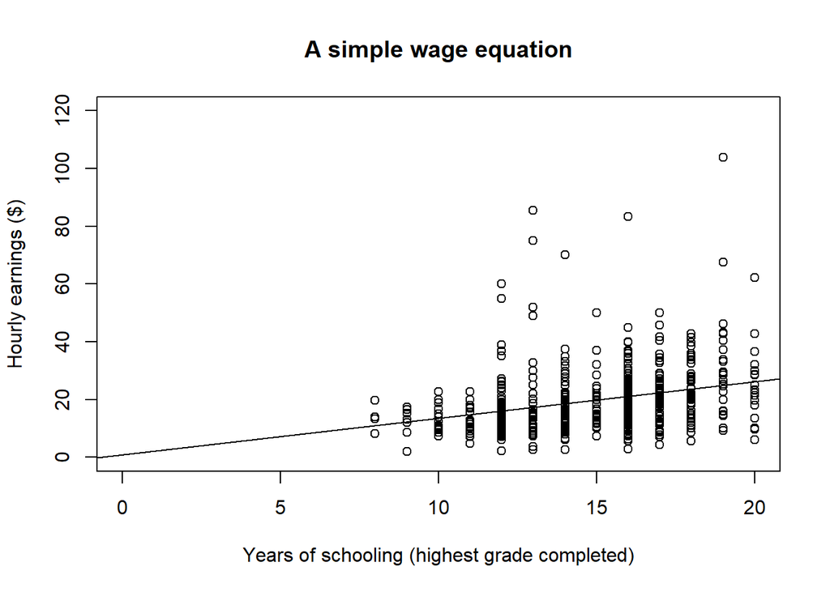

```r
# EARNINGS regress on schooling
# Plot the data
plot(EARNINGS ~ S,
     data = eawe21,
     main = "A simple wage equation",
     xlab = "Years of schooling (highest grade completed)",
     ylab = "Hourly earnings ($)",
     xlim = c(0, 20),
     ylim = c(0, 120))

abline(lin.model)              # Add the regression line
```

#### Demeaning

Often the intercept in a regression equation has no sensible interpretation because $X=0$ is distant from the data range. The wage equation above is an example, with the intercept being implausibly low.  
Sometimes it is useful to deal with the problem by defining $X^*$ as the deviation of $X$ about its sample mean

$$X_{i}^{*}=X_i-\overline{X}$$
and regressing $Y$ on $X^*$. The slope coefficient will not be affected, but the intercept will now be the fitted value of $Y$ at the sample mean of $X$.
The following R code gives the descriptive statistics of `S`. This gives the mean years of schooling was 14.87.

```r
# Descriptive statistics for S
summary(eawe21$S)
```

```
##    Min. 1st Qu.  Median    Mean 3rd Qu.    Max.
##    8.00   12.00   15.00   14.87   17.00   20.00
```

We then regress `EARNINGS` on the demeaned variable `SDEV`, where
$$SDEV_i=S_i-\overline{S}$$

```r
# Create the demeaned variable SDEV
library(tidyverse)                  # Load the required package

eawe21 <- read.csv('./Data/EAWE21.csv', header=T)   # Import data
eawe21.dm <- eawe21 %>%
  mutate(SDEV = S - mean(S)) %>%    # Create the demeaned variable
  select(EARNINGS, S, SDEV)         # Select the required columns

# EARNINGS regress on the demeaned variable SDEV
# Using pipe (%>%) operator to simplify the code
lm(EARNINGS ~ SDEV, data = eawe21.dm) %>%        # Run the model
  summary                                        # Print the result
```

```
##
## Call:
## lm(formula = EARNINGS ~ SDEV, data = eawe21.dm)
##
## Residuals:
##     Min      1Q  Median      3Q     Max
## -20.079  -6.726  -2.203   3.451  79.037
##
## Coefficients:
##             Estimate Std. Error t value Pr(>|t|)
## (Intercept)  19.5808     0.5082  38.528  < 2e-16 ***
## SDEV          1.2657     0.1855   6.824 2.58e-11 ***
## ---
## Signif. codes:  0 '***' 0.001 '**' 0.01 '*' 0.05 '.' 0.1 ' ' 1
##
## Residual standard error: 11.36 on 498 degrees of freedom
## Multiple R-squared:  0.08551,    Adjusted R-squared:  0.08368
## F-statistic: 46.57 on 1 and 498 DF,  p-value: 2.579e-11
```

From the regression results, we can see that the coefficient for `SDEV` is 1.27, which is the same as the coefficient of `S` in the original wage equation. However, this regression further predicts that the hourly earnings is $19.58 for the mean years of schooling of 14.87.

## 4. Some important results relating to OLS regressions

These results are valid only if the model includes an intercept. These results hold automatically, irrespective of whether the model is well or poorly specified.

1. The mean value of the residuals is zero
   $$\overline{\hat{u}}=0$$
   As a corollary, the mean of the fitted values of $Y$ is equal to the mean of the actual values of $Y$.
   $$\overline{\hat{Y}}=\overline{Y}$$
2. The sample covariance[^1] between the observations on $X$ and the residuals is zero. Using the normal equation, we can show that $\sum{}{}X_i\hat{u}_i=0$. Together with the fact that $\overline{\hat{u}}=0$, we can show that the sample covariance between $X$ and $\hat{u}$ is $0$, that is:
   $$\frac{1}{n}\sum_{i=1}^{n}(X_i-\overline{X})(\hat{u}_i-\overline{\hat{u}})=0$$
   Hence the correlation coefficient[^2] is also zero, provided that the sample variances of $X$ and $\hat{u}$ are both nonzero.
   As a corollary, the fitted values of the dependent variable are uncorrelated with the residuals in a simple regression model.
3. The fitted line must pass through the point {$\overline{X}$,$\overline{Y}$} representing the mean of the observations in the sample.

## 5. Goodness of fit: $R^2$

The variations in $Y$ in any sample can be summarized by
$$TSS=\sum(Y_i-\overline{Y})^2$$
where *TSS* is the **total sume of squares**, the sume of the squared deviations about its sample mean.
After fitting a regresseion:
$$Y_i=\hat{Y}_i+\hat{u}_i$$
We can use this to decompose $\sum(Y_i-\overline{Y})^2$:
$$\sum_{i=1}^{n}(Y_i-\overline{Y})^2=\sum_{i=1}^{n}([\hat{Y}_i+\hat{u}_i]-[\overline{\hat{Y}}+\overline{\hat{u}}])^2$$
After some algebraic manipulation, we have:
$$\sum_{i=1}^{n}(Y_i-\overline{Y})^2=\sum_{i=1}^{n}(\hat{Y}_i-\overline{Y})^2+\sum_{i=1}^{n}\hat{u}_i^2$$
Thus we have the decomposition
$$TSS=ESS+RSS$$
where *ESS*, the **explained sum of squares**, and *RSS*, the **residual sume of squares**, are the two terms on the right side.

#### Coefficient of determination

The proportion of the total sum of squares explained by the regression line is known as the **coefficient of determination** or, more usually, $R^2$:

$$R^2=\frac{ESS}{TSS}=\frac{\sum_{i=1}^{n}(\hat{Y}_i-\overline{Y})^2}{\sum_{i=1}^{n}(Y_i-\overline{Y})^2}$$
The value of *ESS* and *RSS* are provided by the command `anova()` in `R`.

```r
# EARNINGS regress on schooling
# Analysis of variance table
anova(lin.model)
```

```
## Analysis of Variance Table
##
## Response: EARNINGS
##            Df Sum Sq Mean Sq F value    Pr(>F)
## S           1   6014  6014.0  46.568 2.579e-11 ***
## Residuals 498  64315   129.1
## ---
## Signif. codes:  0 '***' 0.001 '**' 0.01 '*' 0.05 '.' 0.1 ' ' 1
```

*ESS*, which is described as the independent variable `S` sum of squares, is $6,014$. *TSS* is the sum of *ESS* and the *RSS*, which is described as `Residual` sum of squares, is 64,315. Hence, $TSS=6,014+64,315=70,329$. Dividing *ESS* by *TSS*, we have $R^2=0.08551$, which is given by the command `summary()` in `R`.

```r
# EARNINGS regress on schooling
# Summary of regression results, including the coefficient of determination
summary(lin.model)
```

```
##
## Call:
## lm(formula = EARNINGS ~ S, data = eawe21)
##
## Residuals:
##     Min      1Q  Median      3Q     Max
## -20.079  -6.726  -2.203   3.451  79.037
##
## Coefficients:
##             Estimate Std. Error t value Pr(>|t|)
## (Intercept)   0.7647     2.8038   0.273    0.785
## S             1.2657     0.1855   6.824 2.58e-11 ***
## ---
## Signif. codes:  0 '***' 0.001 '**' 0.01 '*' 0.05 '.' 0.1 ' ' 1
##
## Residual standard error: 11.36 on 498 degrees of freedom
## Multiple R-squared:  0.08551,    Adjusted R-squared:  0.08368
## F-statistic: 46.57 on 1 and 498 DF,  p-value: 2.579e-11
```

Other things being equal, one would like $R^2$ to be as high as possible. In particular, we would like the coefficients $\hat{\beta}_1$ and $\hat{\beta}_2$ should be chosen in such a way as to maximize $R^2$. On the other hand, the coefficients $\hat{\beta}_1$ and $\hat{\beta}_2$ should be chosen to minimize the sum of the squares of the residuals. In fact, the two criteria are equivalent since we can rewrite $R^2$ as:
$$R^2=1-\frac{RSS}{TSS}=1-\frac{\sum_{i=1}^{n}\hat{u}_i^2}{\sum_{i=1}^{n}(Y_i-\overline{Y})^2}$$

Since $\hat{\beta}_1$ and $\hat{\beta}_2$ minimize the residual sum of squares, they automatically maximize $R^2$.

#### Alternative interpretation of $R^2$

It should be intuitively obvious that the better is the fit achieved by the regression equation, the higher should be the correlation coefficient for the actual and predicted values of $Y$, which the correlation coefficient is denoted as $r_{Y,\hat{Y}}$:

$$r_{Y,\hat{Y}}=\frac{\sum_{i=1}^{n}(Y_i-\overline{Y})(\hat{Y}_i-\overline{Y})}{\sqrt{\sum_{i=1}^{n}(Y_i-\overline{Y})^2\sum_{i=1}^{n}(\hat{Y}_i-\overline{Y})^2}}$$
After some algebraic manipulation, we have:

$$r_{Y,\hat{Y}}=\sqrt{R^2}$$

[^1]: By definition, $Cov(X,Y)=E[(X-E[X])(Y-E[Y])]$. Hence, $Cov(X,\hat{u})=E[(X-E[X])(\hat{u}-E[\hat{u}])]=\frac{1}{n}\sum_{i=1}^{n}[(X_i-E[X])(\hat{u}_i-E(\hat{u})]$.
[^2]: The correlation of two random variables $X$ and $Y$, denoted by $\rho(X,Y)$, is defined as $\rho(X,Y)=\frac{Cov(X,Y)}{\sqrt{Var(X)Var(Y)}}$